# Analysis of GSE118337: protective effects of SGLT2 inhibitors in human proximal tubular cells

Gordon K. Smyth

First version 29 April 2026, Last revised 30 April 2026

# Introduction

This case study analyses Agilent-026652 Whole Human Genome Microarray 4x44Kv2 data downloaded from https://www.ncbi.nlm.nih.gov/geo/query/acc.cgi?acc=GSE118337 using the limma package.

This vignette was made with limma version 3.67.3.

# Read sample information

```r
> library(limma)
> Targets <- read.delim("targets.txt")
> Targets$FileName <- paste0(Targets$Accession,"_",Targets$ID,".txt.gz")
> Targets
```

```
    Accession  ID   Condition              FileName
1  GSM3325550 465    HK2_ctrl GSM3325550_465.txt.gz
2  GSM3325551 466    HK2_TGFB GSM3325551_466.txt.gz
3  GSM3325552 467    HK2_Empa GSM3325552_467.txt.gz
4  GSM3325553 468    HK2_Cana GSM3325553_468.txt.gz
5  GSM3325554 469  RPTEC_ctrl GSM3325554_469.txt.gz
6  GSM3325555 470  RPTEC_TGFB GSM3325555_470.txt.gz
7  GSM3325556 471   RPTEC_Emp GSM3325556_471.txt.gz
8  GSM3325557 472  RPTEC_Cana GSM3325557_472.txt.gz
9  GSM3325558 473   HK2_ctrl2 GSM3325558_473.txt.gz
10 GSM3325559 474   HK2_TGFB2 GSM3325559_474.txt.gz
11 GSM3325560 475   HK2_Empa2 GSM3325560_475.txt.gz
12 GSM3325561 476   HK2_Cana2 GSM3325561_476.txt.gz
13 GSM3325562 477 RPTEC_ctrl2 GSM3325562_477.txt.gz
14 GSM3325563 478 RPTEC_TGFB2 GSM3325563_478.txt.gz
15 GSM3325564 479 RPTEC_Empa2 GSM3325564_479.txt.gz
16 GSM3325565 480 RPTEC_Cana2 GSM3325565_480.txt.gz
```

# Read probe intensities

```r
> x <- read.maimages(Targets, source="agilent",
+      green.only=TRUE, other.columns="gIsWellAboveBG")
```

```
Read GSM3325550_465.txt.gz
Read GSM3325551_466.txt.gz
Read GSM3325552_467.txt.gz
Read GSM3325553_468.txt.gz
Read GSM3325554_469.txt.gz
Read GSM3325555_470.txt.gz
Read GSM3325556_471.txt.gz
Read GSM3325557_472.txt.gz
Read GSM3325558_473.txt.gz
Read GSM3325559_474.txt.gz
Read GSM3325560_475.txt.gz
Read GSM3325561_476.txt.gz
Read GSM3325562_477.txt.gz
Read GSM3325563_478.txt.gz
Read GSM3325564_479.txt.gz
Read GSM3325565_480.txt.gz
```

```r
> colnames(x) <- Targets$Condition
> x$targets <- Targets
> dim(x)
```

```
[1] 44495    16
```

# Background correct and normalize

```r
> y <- backgroundCorrect(x, method="normexp")
```

```
Array 1 corrected
Array 2 corrected
Array 3 corrected
Array 4 corrected
Array 5 corrected
Array 6 corrected
Array 7 corrected
Array 8 corrected
Array 9 corrected
Array 10 corrected
Array 11 corrected
Array 12 corrected
Array 13 corrected
Array 14 corrected
Array 15 corrected
Array 16 corrected
```

```r
> y <- normalizeBetweenArrays(y, method="quantile")
```

# Gene filtering

We will filter out control probes as indicated by the `ControlType` column:

```r
> NotControl <- y$genes$ControlType==0L
```

We also filter probes that don’t appear to be expressed. We keep probes that are above background on at least two arrays (because there are two replicates of each condition):

```r
> IsExpr <- rowSums(y$other$gIsWellAboveBG > 0) >= 2
```

Now we select the probes to keep in a new data object yfilt:

```r
> yfilt <- y[NotControl & IsExpr, ]
> dim(yfilt)
```

```
[1] 28680    16
```

To be tidy, we remove annotation columns we no longer need:

```r
> yfilt$genes <- yfilt$genes[,c("ProbeName","GeneName","SystematicName")]
> head(yfilt$genes)
```

```
      ProbeName        GeneName  SystematicName
13  A_23_P42935            BRAF       NM_004333
14 A_23_P117082           HEBP1       NM_015987
15   A_23_P2683           RPAP3       NM_024604
16 A_24_P358131 ENST00000404956 ENST00000404956
19  A_32_P14850         NPIPB15 ENST00000429990
20 A_23_P158596          AGTRAP    NM_001040196
```

# Data exploration

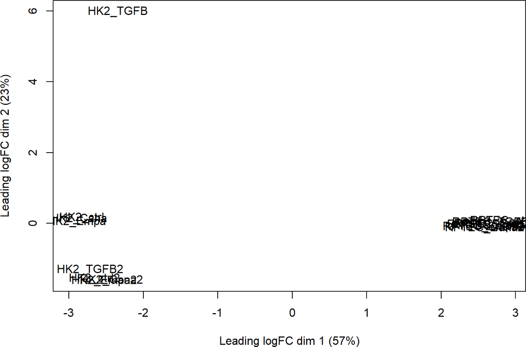

```r
> plotMDS(yfilt)
```

Sample 466 is a spectacular outlier, so we will remove it.

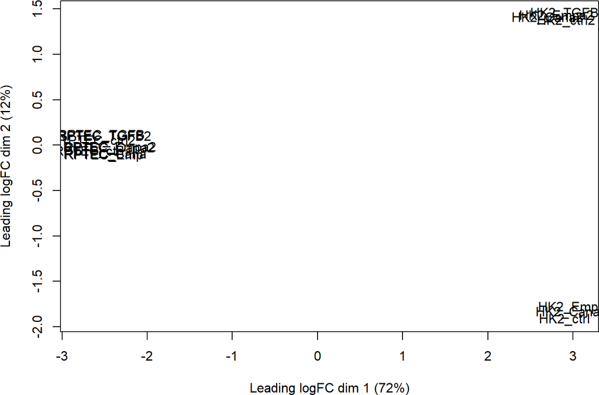

```r
> yfilt <- yfilt[,-2]
> plotMDS(yfilt)
```

The two cell lines are so different that I am inclined to analyse them separately:

```r
> s <- strsplit2(yfilt$targets$Condition, split="_")
> yfilt$targets$CellLine <- s[,1]
> yfilt$targets$Treat <- s[,2]
```

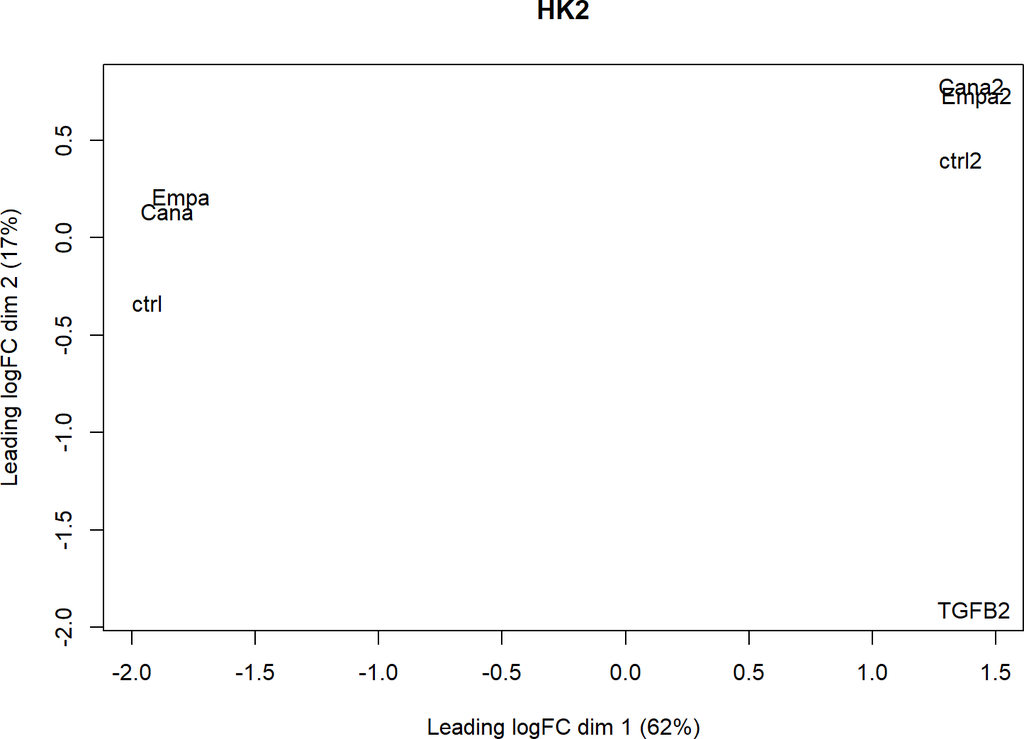

```r
> y.HK2 <- yfilt[,yfilt$targets$CellLine=="HK2"]
> plotMDS(y.HK2, main="HK2", label=y.HK2$targets$Treat)
```

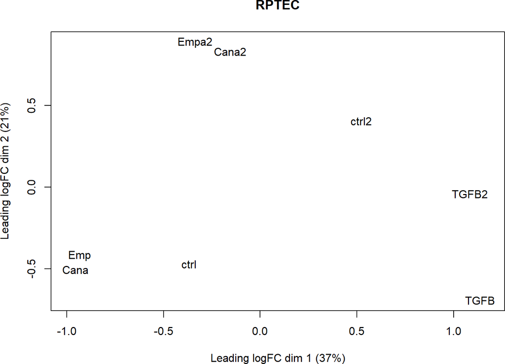

```r
> y.RPTEC <- yfilt[,yfilt$targets$CellLine=="RPTEC"]
> plotMDS(y.RPTEC, main="RPTEC", label=y.RPTEC$targets$Treat)
```

There is a strong replicate effect for both cell lines, but especially for HK2.

## Differential expression for HK2

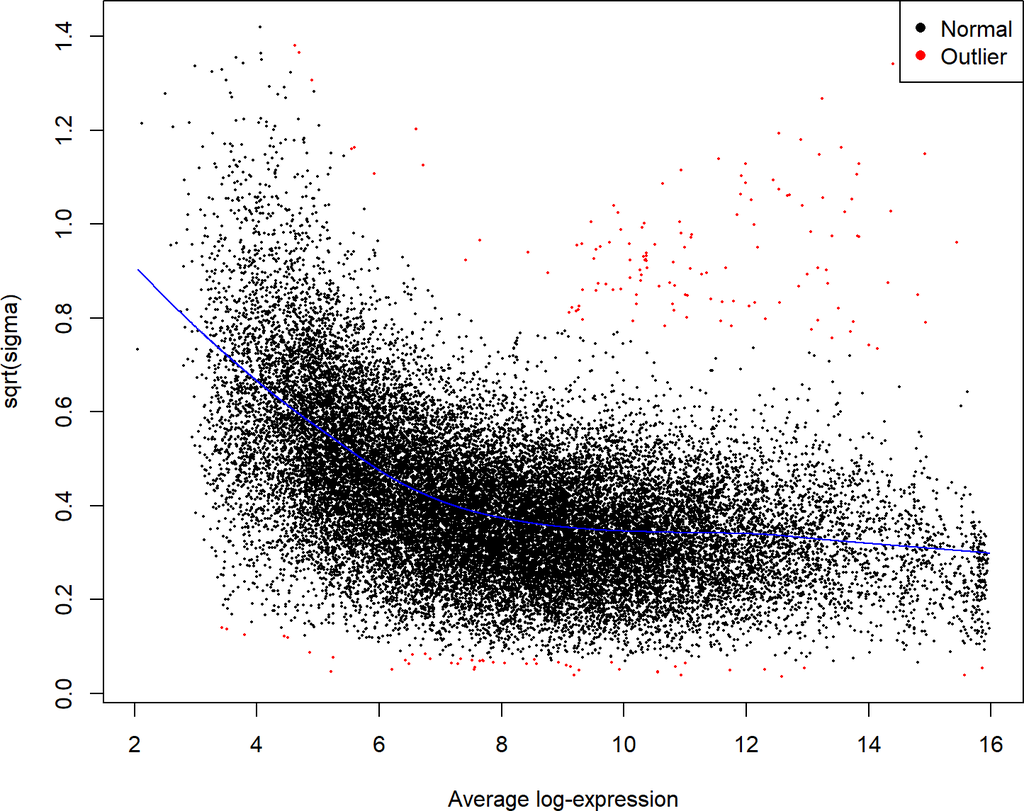

```r
> Replicate <- factor(c(1,1,1,2,2,2,2))
> Treat <- factor(c(1,3,4,1,2,3,4))
> levels(Treat) <- c("ctrl","TBFB","Empa","Cana")
> design <- model.matrix(~Treat+Replicate)
> fit.HK2 <- lmFit(y.HK2,design)
> fit.HK2 <- eBayes(fit.HK2,trend=TRUE,robust=TRUE)
> plotSA(fit.HK2)
```

```r
> summary(decideTests(fit.HK2))
```

```
       (Intercept) TreatTBFB TreatEmpa TreatCana Replicate2
Down             0       963       602       634       5627
NotSig           4     26729     27552     27522      14768
Up           28676       988       526       524       8285
```

```r
> topTable(fit.HK2,coef="TreatTBFB",n=30)
```

```
          ProbeName GeneName SystematicName  logFC AveExpr      t   P.Value adj.P.Val      B
9351  A_33_P3252286    CRLF1      NM_004750  5.829   7.505  33.89 1.433e-09 2.492e-05 11.527
1875   A_24_P413126   PMEPA1      NM_020182  4.567   8.848  32.05 2.182e-09 2.492e-05 11.284
16125  A_23_P122924    INHBA      NM_002192  4.727   7.994  30.20 3.421e-09 2.492e-05 11.009
20973  A_23_P122924    INHBA      NM_002192  4.757   8.025  29.79 3.795e-09 2.492e-05 10.944
27759  A_23_P122924    INHBA      NM_002192  4.729   7.955  28.74 4.978e-09 2.492e-05 10.769
43023  A_23_P122924    INHBA      NM_002192  4.709   7.649  28.03 6.011e-09 2.492e-05 10.644
10056  A_23_P122924    INHBA      NM_002192  4.605   7.926  27.98 6.081e-09 2.492e-05 10.636
25227  A_23_P122924    INHBA      NM_002192  4.844   8.172  26.91 8.169e-09 2.650e-05 10.436
39212  A_23_P122924    INHBA      NM_002192  4.787   7.614  26.81 8.398e-09 2.650e-05 10.417
21019 A_33_P3243887     IL11      NM_000641  5.986   7.217  26.47 9.241e-09 2.650e-05 10.350
26437  A_23_P122924    INHBA      NM_002192  4.681   7.928  25.94 1.075e-08 2.802e-05 10.244
30991  A_32_P351968  HLA-DMB      NM_002118 -3.582  11.732 -25.64 1.174e-08 2.805e-05 10.181
3696  A_33_P3403867   PMEPA1      NM_020182  4.568   8.301  25.27 1.311e-08 2.892e-05 10.102
29224  A_23_P122924    INHBA      NM_002192  4.860   8.105  24.91 1.459e-08 2.934e-05 10.024
```

[output cut: 16 more lines]

Each coefficient compares that treatment to the control.

## Differential expression for RPTEC

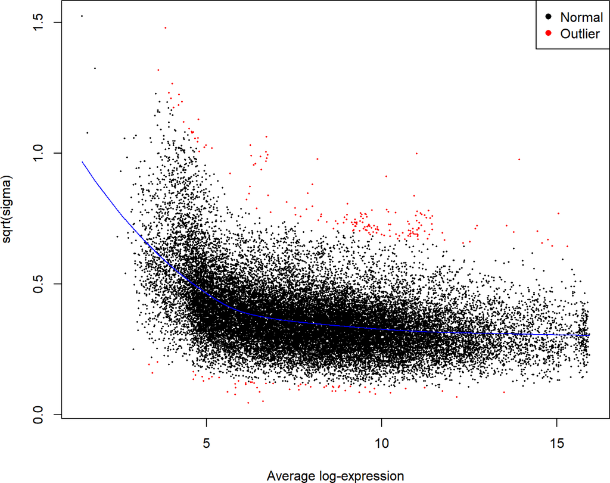

```r
> Replicate <- factor(c(1,1,1,1,2,2,2,2))
> Treat <- factor(c(1,2,3,4,1,2,3,4))
> levels(Treat) <- c("ctrl","TBFB","Empa","Cana")
> design <- model.matrix(~Treat+Replicate)
> fit.RPTEC <- lmFit(y.RPTEC,design)
> fit.RPTEC <- eBayes(fit.RPTEC,trend=TRUE,robust=TRUE)
> plotSA(fit.RPTEC)
```

```r
> summary(decideTests(fit.RPTEC))
```

```
       (Intercept) TreatTBFB TreatEmpa TreatCana Replicate2
Down             0        58       662       562       6450
NotSig           2     28285     27580     27712      17083
Up           28678       337       438       406       5147
```

```r
> topTable(fit.RPTEC,coef="TreatTBFB",n=30)
```

```
          ProbeName      GeneName SystematicName  logFC AveExpr      t   P.Value adj.P.Val     B
26092  A_23_P215634        IGFBP3   NM_001013398 1.6180  10.939 15.245 1.043e-07  0.001744 7.661
8691   A_23_P379649           BMF   NM_001003940 1.6676   7.315 14.608 1.509e-07  0.001744 7.401
26223 A_33_P3293009        NKAIN4      NM_152864 1.8552  11.117 14.511 1.825e-07  0.001744 7.241
21483  A_23_P215634        IGFBP3   NM_001013398 1.5849  10.941 12.899 4.386e-07  0.001945 6.607
19438   A_23_P40174          MMP9      NM_004994 2.3559   6.193 12.955 4.437e-07  0.001945 6.592
34760  A_23_P144071        COL7A1      NM_000094 1.6681   8.646 12.564 5.490e-07  0.001945 6.432
27207  A_23_P215634        IGFBP3   NM_001013398 1.5553  11.184 12.489 6.135e-07  0.001945 6.339
14484  A_23_P215634        IGFBP3   NM_001013398 1.5556  10.996 12.438 6.309e-07  0.001945 6.317
25177   A_23_P87011         TAGLN   NM_001001522 1.6685   8.307 12.172 7.184e-07  0.001945 6.220
27759  A_23_P122924         INHBA      NM_002192 2.7901   5.466 12.232 7.736e-07  0.001945 6.150
9741   A_23_P215634        IGFBP3   NM_001013398 1.5742  10.896 12.205 7.882e-07  0.001945 6.135
37537  A_23_P215634        IGFBP3   NM_001013398 1.5864  10.637 12.158 8.136e-07  0.001945 6.110
30457   A_23_P40174          MMP9      NM_004994 2.3105   6.118 11.755 1.186e-06  0.002125 5.799
41798   A_23_P17316        NKAIN4      NM_152864 1.9709   6.893 11.561 1.239e-06  0.002125 5.771
```

[output cut: 16 more lines]

The HK2 and RPTEC results are correlated:

```r
> cor(fit.HK2$coef[,2:4], fit.RPTEC$coef[,2:4])
```

```
          TreatTBFB TreatEmpa TreatCana
TreatTBFB   0.34294  -0.03873  -0.06799
TreatEmpa  -0.08158   0.17789   0.16463
TreatCana  -0.06694   0.17505   0.15339
```

# Further reading

More limma documentation and example analyses are available from https://github.com/SmythLab/limma/.